# EIOM 2024 Partie 3 - Classification non-supervisée

Author

Anne-Sophie Charest

Published

August 30, 2024

Charger les librairies nécessaires :

```r
library(ggplot2)
library(factoextra)
library(tidyverse)
library(NbClust)
```

# 1 Méthode k-moyennes

On utilisera de nouveau les données USArrests. Rappelons qu’elles donnent pour 50 états américains le nombre d’arrestations par 100 000 habitants pour meutre, agression et viol ainsi que la proportion de la population vivant en centre urbain, tout cela pour l’année 1973.

## 1.1 Exemple avec USArrest et scale = TRUE

On suggère généralement de mettre à l’échelle les variables avant d’utiliser l’algorithm k-moyennes donc c’est ce qu’on fera ici, avec la fonction `kmeans` qui vient avec R. Il est aussi mieux de toujours utiliser plus d’un point de départ aléatoire afin de s’assurer d’obtenir le maximum global.

```r
kmeans_USArrests_4 <- kmeans(scale(USArrests), centers = 4, nstart = 10)
kmeans_USArrests_4
```

```
K-means clustering with 4 clusters of sizes 13, 8, 13, 16

Cluster means:
      Murder    Assault   UrbanPop        Rape
1 -0.9615407 -1.1066010 -0.9301069 -0.96676331
2  1.4118898  0.8743346 -0.8145211  0.01927104
3  0.6950701  1.0394414  0.7226370  1.27693964
4 -0.4894375 -0.3826001  0.5758298 -0.26165379

Clustering vector:
       Alabama         Alaska        Arizona       Arkansas     California
             2              3              3              2              3
      Colorado    Connecticut       Delaware        Florida        Georgia
             3              4              4              3              2
        Hawaii          Idaho       Illinois        Indiana           Iowa
             4              1              3              4              1
        Kansas       Kentucky      Louisiana          Maine       Maryland
             4              1              2              1              3
 Massachusetts       Michigan      Minnesota    Mississippi       Missouri
             4              3              1              2              3
       Montana       Nebraska         Nevada  New Hampshire     New Jersey
             1              1              3              1              4
    New Mexico       New York North Carolina   North Dakota           Ohio
             3              3              2              1              4
      Oklahoma         Oregon   Pennsylvania   Rhode Island South Carolina
             4              4              4              4              2
  South Dakota      Tennessee          Texas           Utah        Vermont
             1              2              3              4              1
      Virginia     Washington  West Virginia      Wisconsin        Wyoming
             4              4              1              1              4

Within cluster sum of squares by cluster:
[1] 11.952463  8.316061 19.922437 16.212213
 (between_SS / total_SS =  71.2 %)

Available components:

[1] "cluster"      "centers"      "totss"        "withinss"     "tot.withinss"
[6] "betweenss"    "size"         "iter"         "ifault"
```

L’objet produit les moyennes de toutes les variables pour chacun des groupes, l’assignation de chacune des observations ainsi que de l’information sur la qualité de la classification.

Vous devriez être capable de répondre aux questions ci-dessous :  
- Combien y-a-t-il d’observations dans le troisième groupe?  
- Quel groupe contient les états avec le moins de meutres par habitant?  
- Est-ce que le Maine et le Vermont sont dans le même groupe?  
- Quel groupe est le plus homogène?  
**Vos notes ici:**

Il peut être intéressant de visualiser les résultats, surtout qu’on a ici que peu de variables. On peut simplement le faire à l’aide des fonction de base, en ajoutant la couleur correspondant au groupe auquel chaque observation appartient.

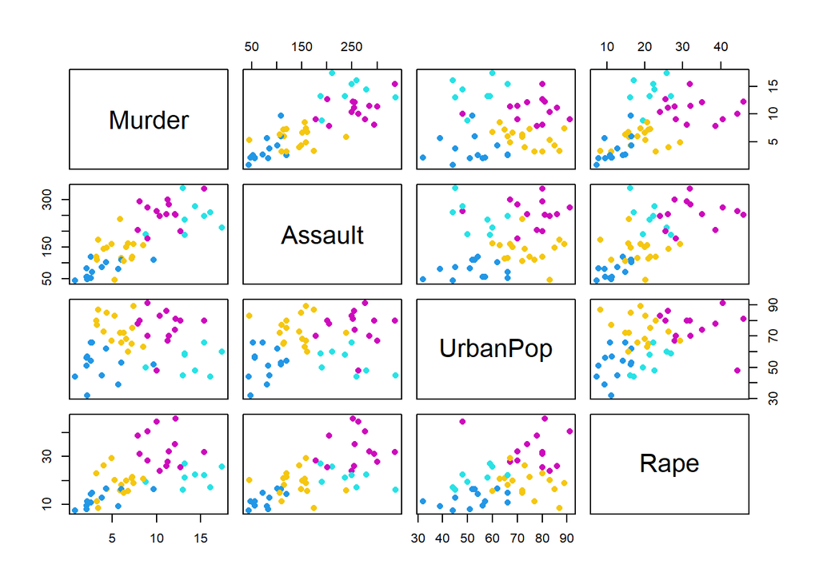

```r
pairs(USArrests, col = kmeans_USArrests_4$cluster+3, pch = 16)
```

La librairie `factoextra` contient une autre fonction pour visualiser rapidement les différents groupes.

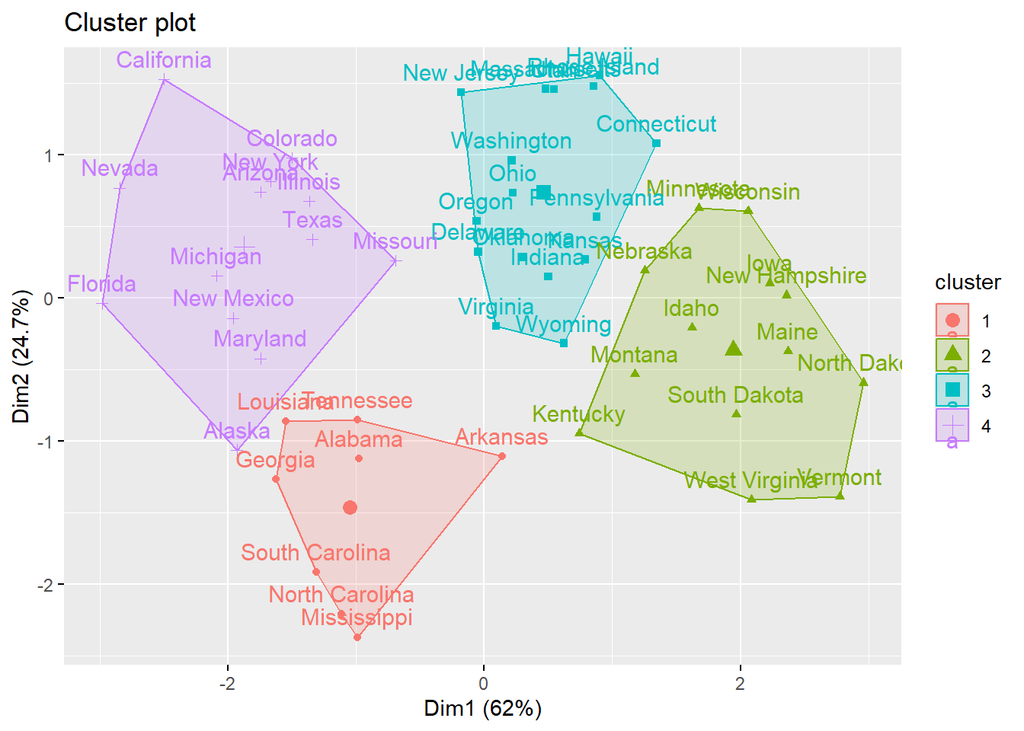

```r
fviz_cluster(kmeans(scale(USArrests),4, nstart = 10),USArrests)
```

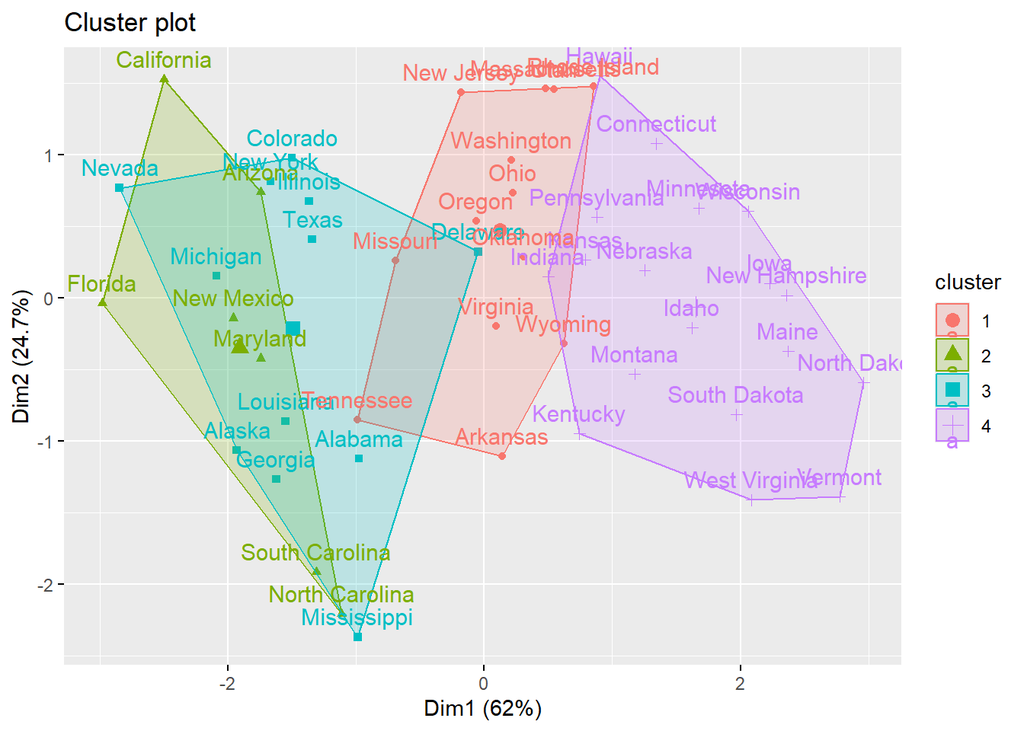

```r
fviz_cluster(kmeans(USArrests,4),USArrests)
```

Que représentent les axes? les polygones? **Vos notes ici:**

L’exemple ici permet en outre de voir facilement l’importance d’utiliser plusieurs points de départ différents. ROulez le code ci-dessous à plusieurs reprises. Que remarquez-vous? Comparez avec le résultat obtenu plus haut.

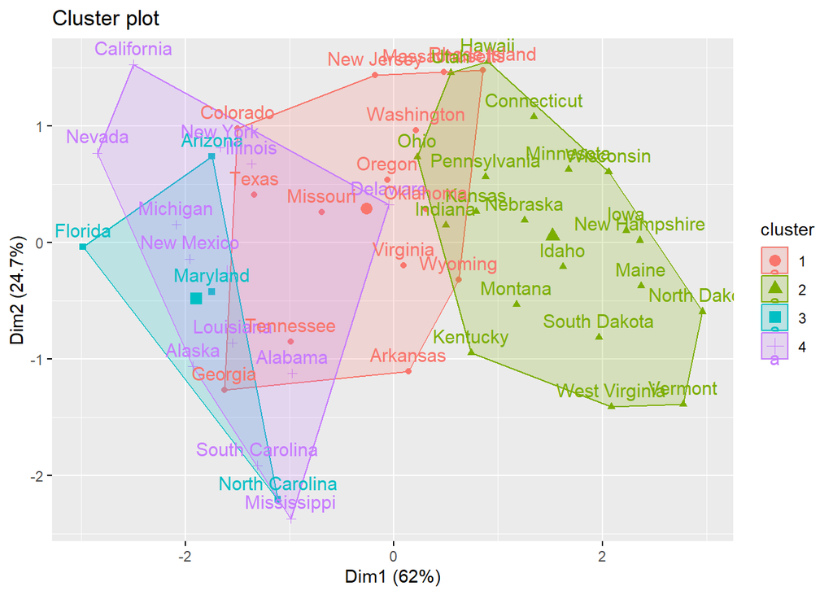

```r
fviz_cluster(kmeans(USArrests,4),USArrests)
```

**Vos notes ici:**

## 1.2 Exemple avec USArrest et scale = FALSE

Dans le premier exemple, nous avions standardisé les données avant d’utiliser l’agorithme k-moyennes. Les résultats auraient-ils à votre avis été différents si on avait omis cette étape? Valider votre hypothèse.

```r
# Ajouter votre code ici
```

**Vos notes ici:**

## 1.3 Choisir la valeur de `k`

Dans notre premier exemple, nous avons demandé 4 groupes, mais rien n’indiquait *a priori* que c’était le bon nombre de groupes à utiliser. On voudra habituellement appliquer l’algorithme avec plusieurs choix pour $k$ choisir ensuite le meilleur nombre de groupes selon certains critères.

On peut d’abord regarder les résultats pour différents nombres de groupes.

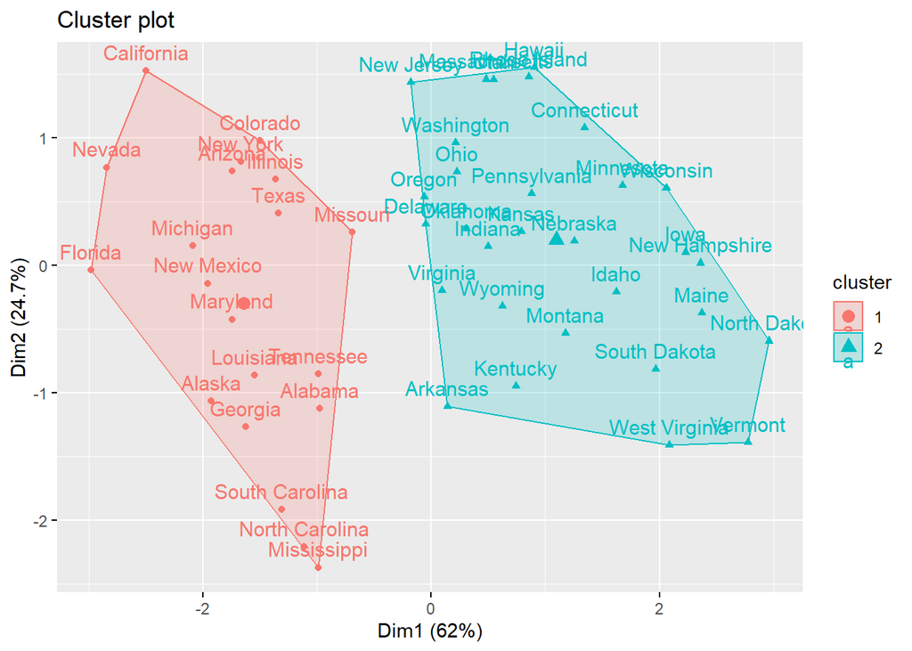

```r
fviz_cluster(kmeans(scale(USArrests),2, nstart=10),USArrests)
```

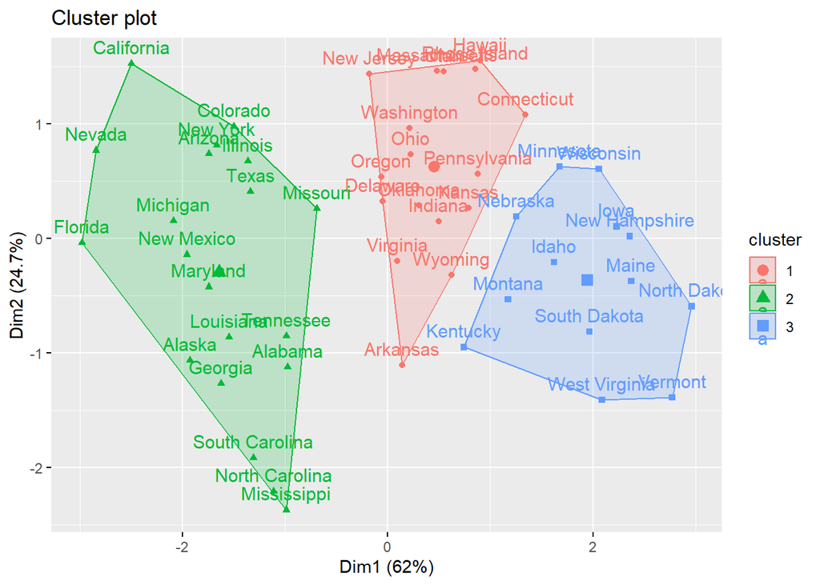

```r
fviz_cluster(kmeans(scale(USArrests),3), nstart=10,USArrests)
```

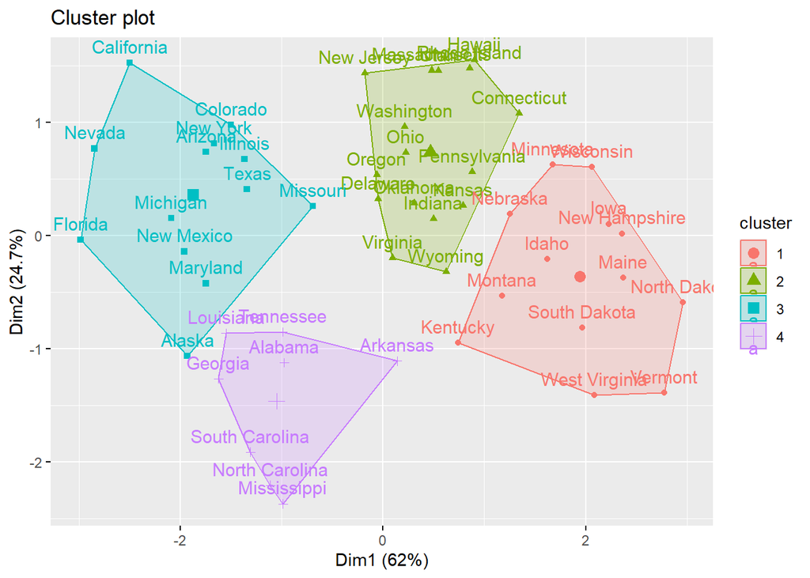

```r
fviz_cluster(kmeans(scale(USArrests),4), nstart=10,USArrests)
```

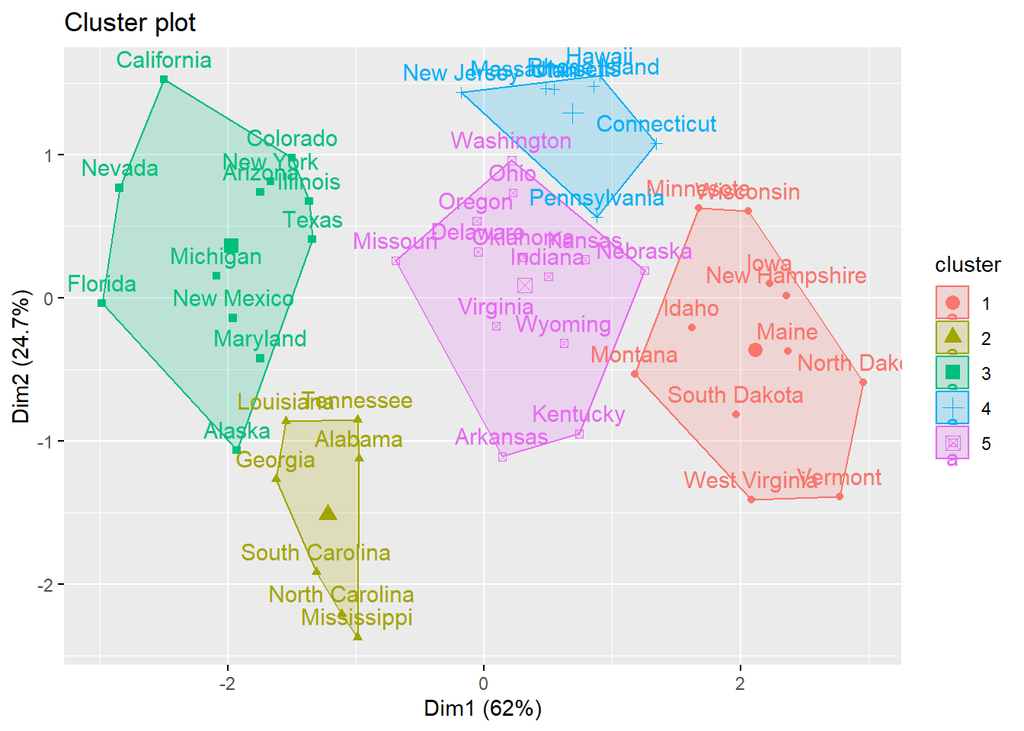

```r
fviz_cluster(kmeans(scale(USArrests),5), nstart=10,USArrests)
```

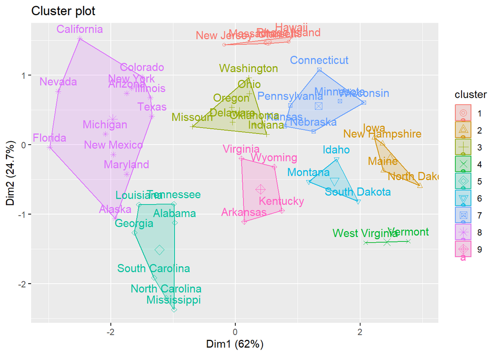

```r
fviz_cluster(kmeans(scale(USArrests),9), nstart=10,USArrests)
```

Notez que ce n’est pas l’idéal de copier-coller le code ainsi. On pourrait écrire une boucle, mais une autre option est d’utiliser la fonction `map` de la librairie `purrr` dans le `tidyverse`. Celle-ci nous retourne une liste avec autant d’éléments que de valeurs de `k` choisies, neuf dans le code ci-dessous, chaque élément étant lui-même une liste avec les résulats de l’algorithm k-moyennes.

```r
USArrests_scaled = scale(USArrests)
out = map(1:9, ~kmeans(USArrests_scaled, .x, nstart = 10))
str(out)
```

```
List of 9
 $ :List of 9
  ..$ cluster     : Named int [1:50] 1 1 1 1 1 1 1 1 1 1 ...
  .. ..- attr(*, "names")= chr [1:50] "Alabama" "Alaska" "Arizona" "Arkansas" ...
  ..$ centers     : num [1, 1:4] -7.16e-17 1.11e-16 -4.07e-16 1.44e-16
  .. ..- attr(*, "dimnames")=List of 2
  .. .. ..$ : chr "1"
  .. .. ..$ : chr [1:4] "Murder" "Assault" "UrbanPop" "Rape"
  ..$ totss       : num 196
  ..$ withinss    : num 196
  ..$ tot.withinss: num 196
  ..$ betweenss   : num -8.53e-14
  ..$ size        : int 50
  ..$ iter        : int 1
  ..$ ifault      : NULL
  ..- attr(*, "class")= chr "kmeans"
 $ :List of 9
  ..$ cluster     : Named int [1:50] 1 1 1 2 1 1 2 2 1 1 ...
  .. ..- attr(*, "names")= chr [1:50] "Alabama" "Alaska" "Arizona" "Arkansas" ...
  ..$ centers     : num [1:2, 1:4] 1.005 -0.67 1.014 -0.676 0.198 ...
  .. ..- attr(*, "dimnames")=List of 2
  .. .. ..$ : chr [1:2] "1" "2"
  .. .. ..$ : chr [1:4] "Murder" "Assault" "UrbanPop" "Rape"
  ..$ totss       : num 196
  ..$ withinss    : num [1:2] 46.7 56.1
  ..$ tot.withinss: num 103
  ..$ betweenss   : num 93.1
  ..$ size        : int [1:2] 20 30
  ..$ iter        : int 1
  ..$ ifault      : int 0
  ..- attr(*, "class")= chr "kmeans"
 $ :List of 9
  ..$ cluster     : Named int [1:50] 2 2 2 3 2 2 3 3 2 2 ...
  .. ..- attr(*, "names")= chr [1:50] "Alabama" "Alaska" "Arizona" "Arkansas" ...
  ..$ centers     : num [1:3, 1:4] -0.962 1.005 -0.447 -1.107 1.014 ...
  .. ..- attr(*, "dimnames")=List of 2
  .. .. ..$ : chr [1:3] "1" "2" "3"
  .. .. ..$ : chr [1:4] "Murder" "Assault" "UrbanPop" "Rape"
  ..$ totss       : num 196
  ..$ withinss    : num [1:3] 12 46.7 19.6
```

[output cut: 81 more lines]

```
 $ :List of 9
  ..$ cluster     : Named int [1:50] 5 7 6 2 8 8 4 9 6 5 ...
  .. ..- attr(*, "names")= chr [1:50] "Alabama" "Alaska" "Arizona" "Arkansas" ...
  ..$ centers     : num [1:9, 1:4] -1.1567 0.00849 -1.11766 -0.69587 1.5804 ...
  .. ..- attr(*, "dimnames")=List of 2
  .. .. ..$ : chr [1:9] "1" "2" "3" "4" ...
  .. .. ..$ : chr [1:4] "Murder" "Assault" "UrbanPop" "Rape"
  ..$ totss       : num 196
  ..$ withinss    : num [1:9] 1.81 1.54 2.2 5.24 6.13 ...
  ..$ tot.withinss: num 29.9
  ..$ betweenss   : num 166
  ..$ size        : int [1:9] 6 4 5 7 7 8 1 3 9
  ..$ iter        : int 3
  ..$ ifault      : int 0
  ..- attr(*, "class")= chr "kmeans"
```

On peut même utiliser des fonctions de la librarie `broom`pour restructurer les résultats obtenus de façon à faciliter la création de graphiques. Pour un exemple, voir https://www.tidymodels.org/learn/statistics/k-means/.

Une autre fonction de la librairie `factoextra` permet de rapidement comparer certains critères pour différentes valeurs de $k$.

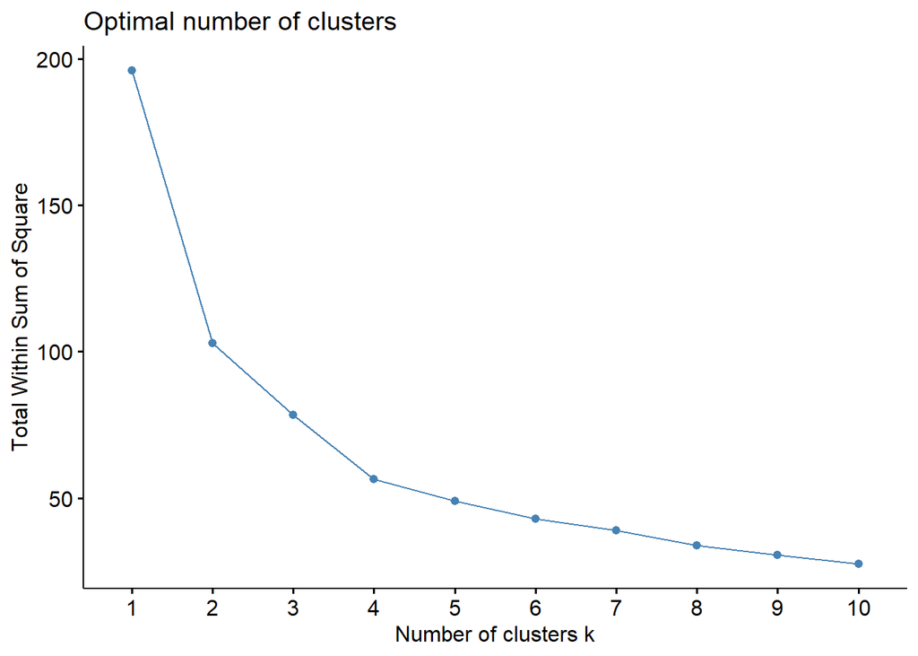

```r
fviz_nbclust(scale(USArrests), kmeans, method = "wss", k.max = 10, nstart=10)
```

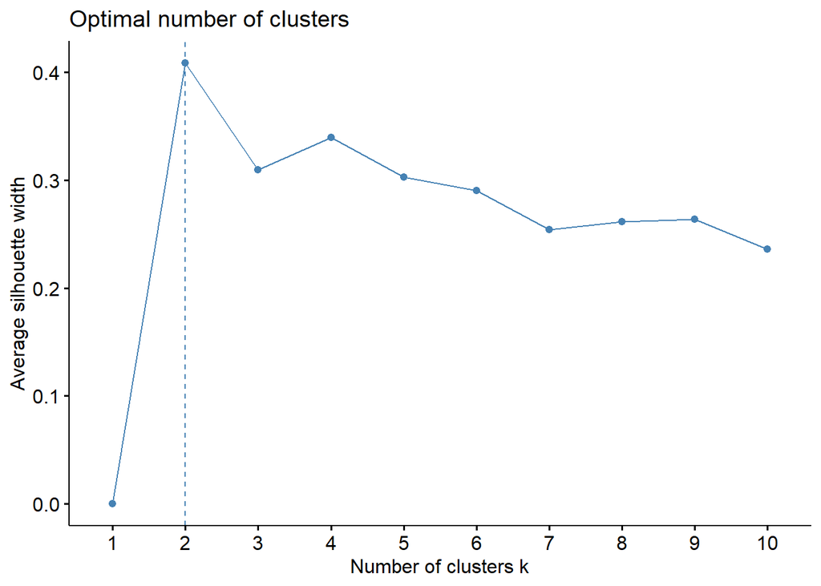

```r
fviz_nbclust(scale(USArrests), kmeans, method = "silhouette", k.max = 10, nstart = 10)
```

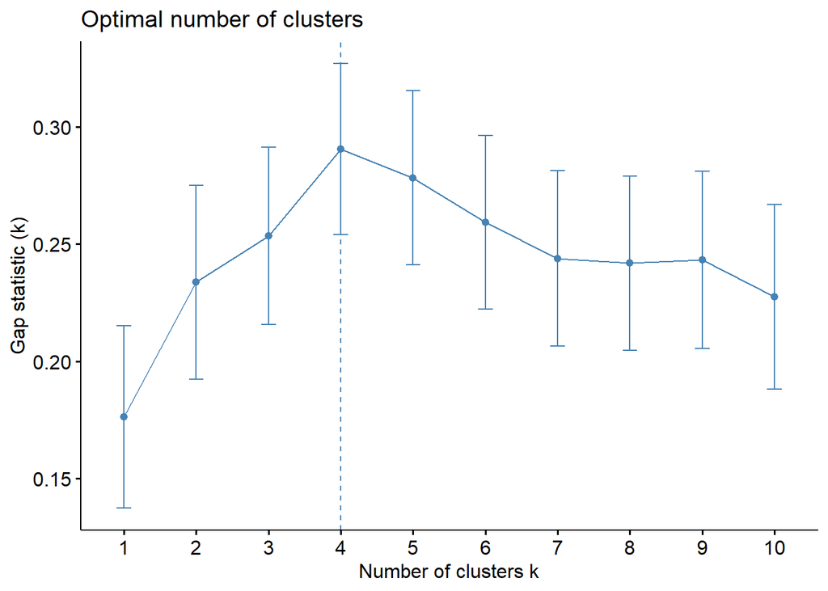

```r
fviz_nbclust(scale(USArrests), kmeans, method = "gap_stat", k.max = 10, nstart = 10)
```

Que concluez-vous? **Vos notes ici:**

Enfin, il y a aussi la librarie NbClust qui fournit encore plus de critères de sélection.

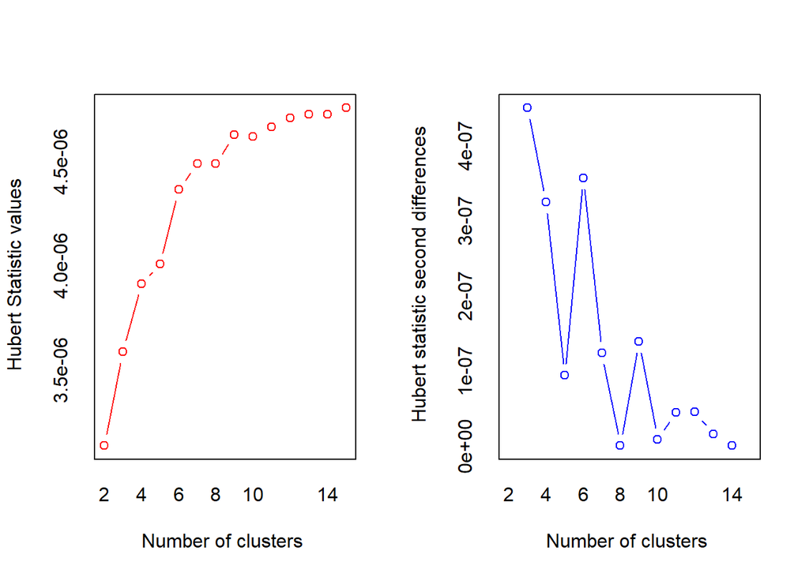

```
*** : The Hubert index is a graphical method of determining the number of clusters.
                In the plot of Hubert index, we seek a significant knee that corresponds to a
                significant increase of the value of the measure i.e the significant peak in Hubert
                index second differences plot.
```

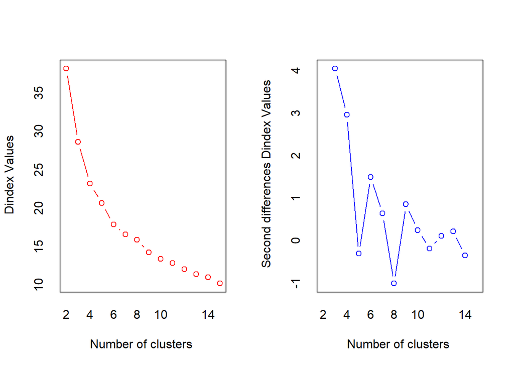

```
*** : The D index is a graphical method of determining the number of clusters.
                In the plot of D index, we seek a significant knee (the significant peak in Dindex
                second differences plot) that corresponds to a significant increase of the value of
                the measure.

* Among all indices:
* 9 proposed 2 as the best number of clusters
* 5 proposed 3 as the best number of clusters
* 1 proposed 4 as the best number of clusters
* 1 proposed 5 as the best number of clusters
* 4 proposed 6 as the best number of clusters
* 3 proposed 9 as the best number of clusters
* 1 proposed 15 as the best number of clusters

                   ***** Conclusion *****

* According to the majority rule, the best number of clusters is  2
```

```
$All.index
       KL       CH Hartigan     CCC    Scott      Marriot     TrCovW    TraceW
2  4.1215 129.1675  48.4708 11.9829 240.1933 1.706298e+15 1569840706 96399.028
3  3.9101 150.8274  17.9125  9.8880 276.7118 1.849448e+15  313176246 47964.265
4  2.1583 141.7624  10.5688  9.5142 303.0814 1.940333e+15  162897241 34728.629
5  0.3674 130.4924  22.7116  8.8851 334.3037 1.623687e+15  106187940 28240.232
6  7.9934 158.0323   5.8556 10.1140 374.1711 1.053371e+15   35949858 18768.001
7  4.5062 146.7820   2.4741  9.4785 389.5599 1.053924e+15   26568495 16563.673
8  0.0660 130.3033  11.2308  8.5144 398.4722 1.151813e+15   25370012 15662.479
9  6.1807 142.4330   3.6251  8.9915 442.9629 5.987502e+14   17636501 12357.952
10 0.6127 134.8334   4.3074  8.4576 459.6052 5.299172e+14   14946023 11354.056
11 0.4752 131.4770   7.1910  8.1242 468.2032 5.398985e+14   11019095 10250.269
12 2.6118 138.5703   3.6900  8.3290 482.8436 4.794283e+14    6724520  8654.503
13 6.6341 135.9895   1.7122  8.0290 495.5012 4.368228e+14    5608888  7888.486
14 0.1271 127.9162   3.8379  7.4265 505.9071 4.114245e+14    4916106  7539.586
```

[output cut: 99 more lines]

```r
library(NbClust)
NbClust(USArrests, method = "kmeans")
```

Que concluez-vous? **Vos notes ici:**

# 2 Classification hiérarchique ascendante

## 2.1 Exemple avec USArrests

En plus de devoir choisir le nombre de groupes pour la classification, on peut tester différentes méthodes de classification hiérarchique ascendante. On montre ici un petit exemple.

On utilise la fonction `hclust` pour faire la classification. On doit donner en entrée une matrice de distances. La fonction `dist` calculera la matrice de distances euclidiennes entre les obervations par défaut, mais on pourrait aussi utiliser d’autres distances si désiré. Encore une fois, on recommande généralement de standardiser le jeu de données avant de calculer les distances.

```r
hc_USArrests <- hclust(dist(scale(USArrests)), method = "average")
hc_USArrests
```

```
Call:
hclust(d = dist(scale(USArrests)), method = "average")

Cluster method   : average
Distance         : euclidean
Number of objects: 50
```

On peut facilement visualiser les résultats. Notez que la deuxième version est plus facile à lire.

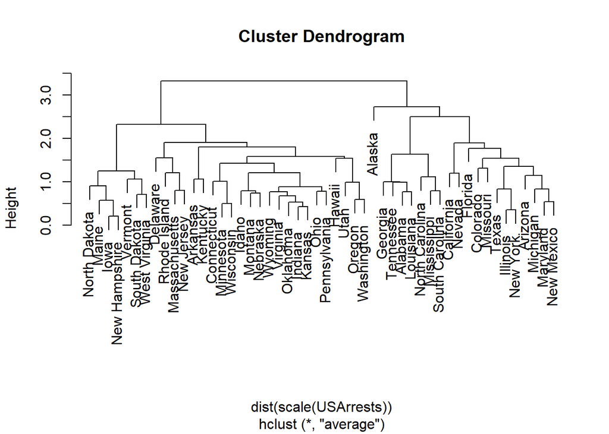

```r
plot(hc_USArrests)
```

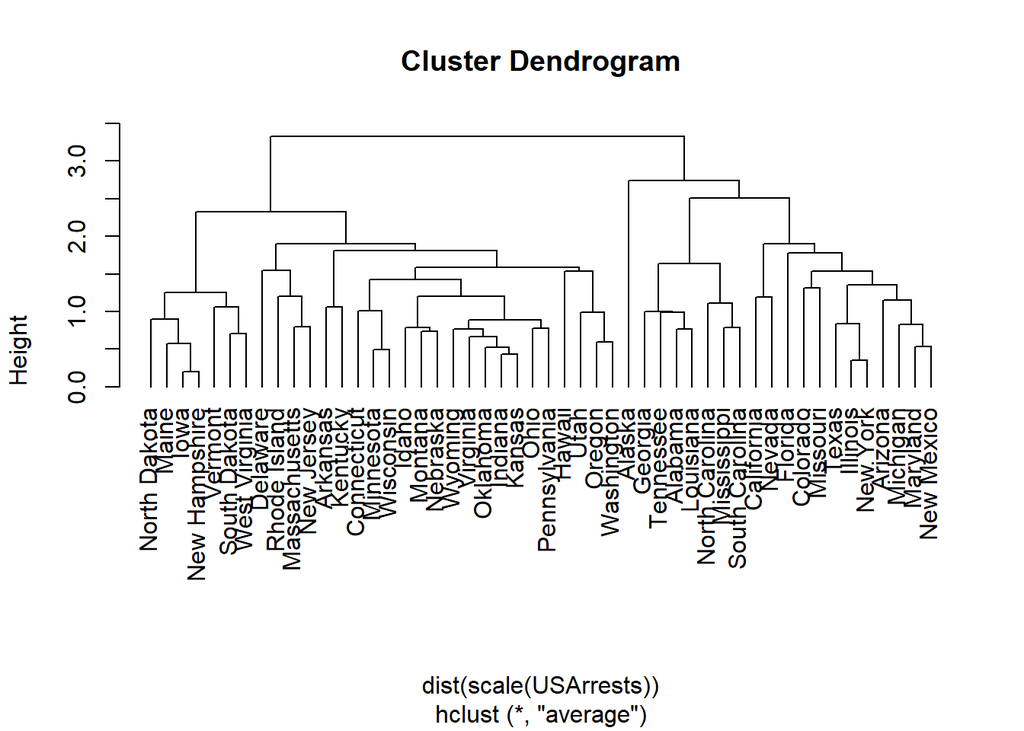

```r
plot(hc_USArrests, hang = -1)
```

La fonction `cutree` permet de couper le dendrogramme à l’endroit approprié pour créer un certain nombre de groupes.

```r
grps = cutree(hc_USArrests, k = 3)
grps
```

```
       Alabama         Alaska        Arizona       Arkansas     California
             1              2              1              3              1
      Colorado    Connecticut       Delaware        Florida        Georgia
             1              3              3              1              1
        Hawaii          Idaho       Illinois        Indiana           Iowa
             3              3              1              3              3
        Kansas       Kentucky      Louisiana          Maine       Maryland
             3              3              1              3              1
 Massachusetts       Michigan      Minnesota    Mississippi       Missouri
             3              1              3              1              1
       Montana       Nebraska         Nevada  New Hampshire     New Jersey
             3              3              1              3              3
    New Mexico       New York North Carolina   North Dakota           Ohio
             1              1              1              3              3
      Oklahoma         Oregon   Pennsylvania   Rhode Island South Carolina
             3              3              3              3              1
  South Dakota      Tennessee          Texas           Utah        Vermont
             3              1              1              3              3
      Virginia     Washington  West Virginia      Wisconsin        Wyoming
             3              3              3              3              3
```

```r
table(grps) #Pour connaitre le nombre d'observations par groupe
```

```
grps
 1  2  3
19  1 30
```

On peut afficher la classification résultante sur le dendrogramme.

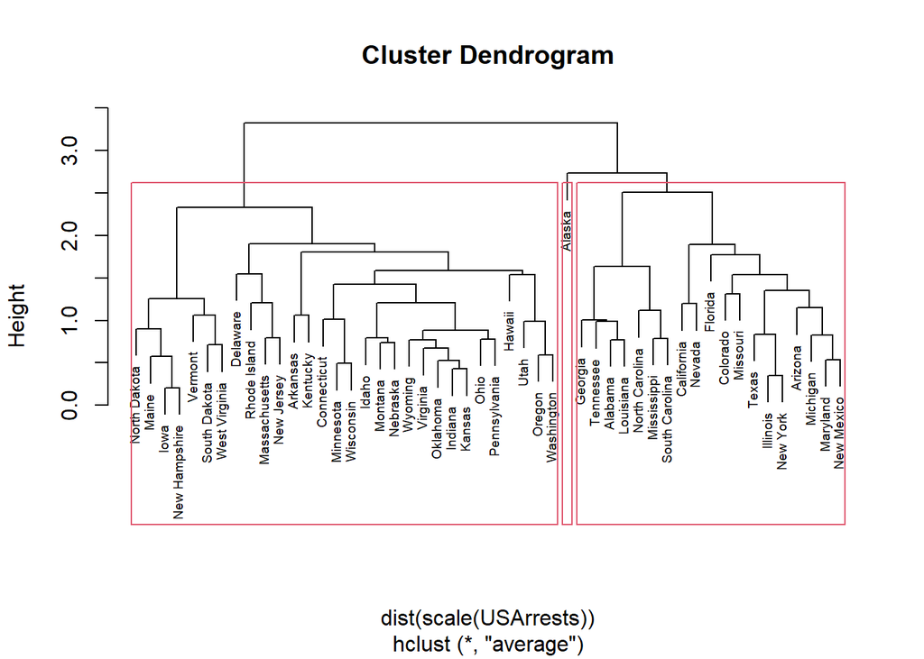

```r
plot(hc_USArrests, cex = 0.6)
rect.hclust(hc_USArrests, k = 3)
```

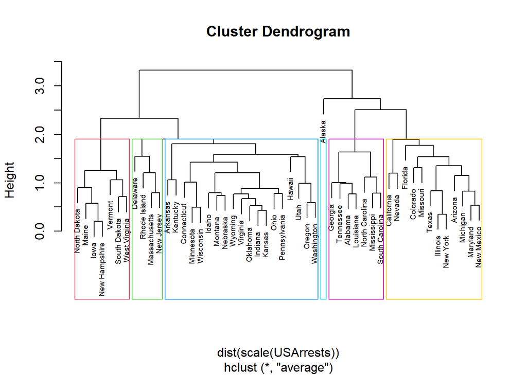

```r
plot(hc_USArrests, cex = 0.6)
rect.hclust(hc_USArrests, k = 6, border = 2:8) #border met des couleurs différentes à chaque groupe
```

Notez qu’il existe des fonctions autres que celles illustrées ici pour faire et visualiser la classification hiérarchique ascendante. Voir par exemple ici : https://www.tidymodels.org/learn/statistics/k-means/